# Survival analysis and event history analysis

Suvi Vainio

# Task 1

*Plot a histogram of the survival times corresponding to uncensored observations (veteran$status == 1) by changing values of nclass and also without nclass.*

Histogram is right skewed: large number of the population dies at the beginning of the calendar time under study.

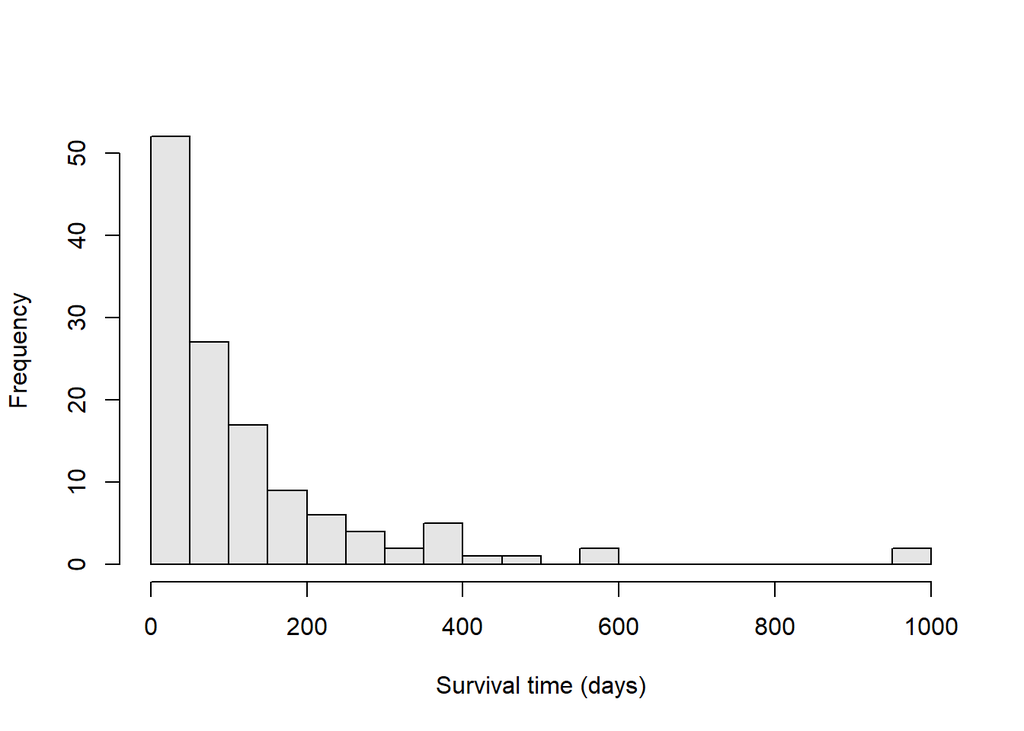

```r
hist(veteran$time[veteran$status == 1], nclass=30, main='', xlab='Survival time (days)',
     col='gray90')
```

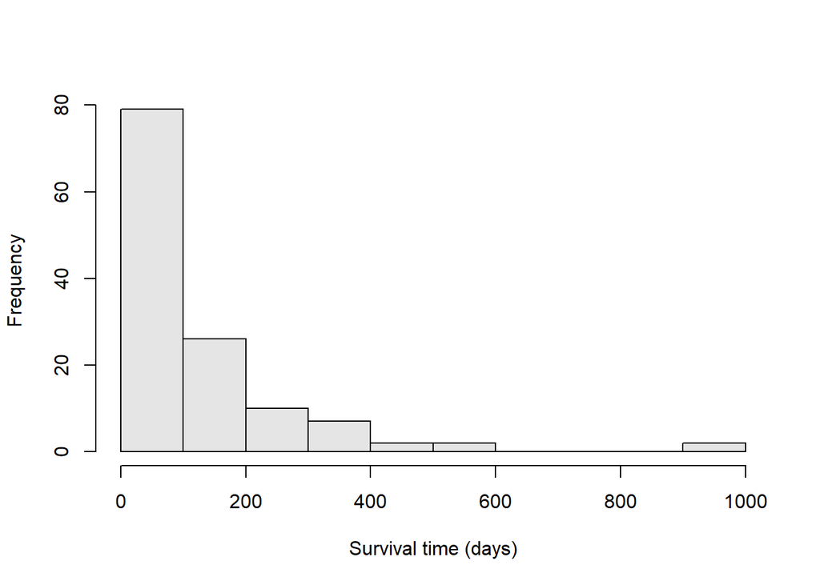

```r
hist(veteran$time[veteran$status == 1], main='', xlab='Survival time (days)',
     col='gray90')
```

```r
# Right skewed data
```

# Task 2

*Create an output file where the histogram is stored. Remember to first defint outpath where the file should be stored.*

(File created)

```r
pdf(file.path(getwd(), 'survtimes.pdf'))
op <- par(mar=c(4,4,0,0), mgp=c(2,1,0))
hist(veteran$time[veteran$status == 1], nclass=30, main='', xlab='Survival time (days)',
     col='gray90')
par(op)
dev.off()
```

# Task 3

## a)

*Use the survifit routine in R to calculate the Kaplan-Meier estimate of the overall survival in the data. In the survival routines of R, the response variable needs to be specified as a survival object. If the observed failure time variable is time and failure indicator variable is status, the response variable is created as Surv(time, status).*

*Applying the plot command to the output object from the survfit routine, you can draw the estimate and its confidence limits. Experiment with different confidence levels (e.g. 80% and 95%). You can also practice with the plot command options (e.g. xlab, ylab).*

```r
#head(veteran)
analyse1=survfit(Surv(time, status)~1, data=veteran) #, conf.type="none")
summary(analyse1)
```

```
## Call: survfit(formula = Surv(time, status) ~ 1, data = veteran)
##
##  time n.risk n.event survival std.err lower 95% CI upper 95% CI
##     1    137       2    0.985 0.01025      0.96552       1.0000
##     2    135       1    0.978 0.01250      0.95390       1.0000
##     3    134       1    0.971 0.01438      0.94302       0.9994
##     4    133       1    0.964 0.01602      0.93261       0.9954
##     7    132       3    0.942 0.02003      0.90315       0.9817
##     8    129       4    0.912 0.02415      0.86628       0.9610
##    10    125       2    0.898 0.02588      0.84850       0.9500
##    11    123       1    0.891 0.02668      0.83973       0.9444
##    12    122       2    0.876 0.02817      0.82241       0.9329
##    13    120       2    0.861 0.02953      0.80534       0.9212
##    15    118       2    0.847 0.03078      0.78849       0.9092
##    16    116       1    0.839 0.03137      0.78013       0.9032
```

[output cut: 85 more lines]

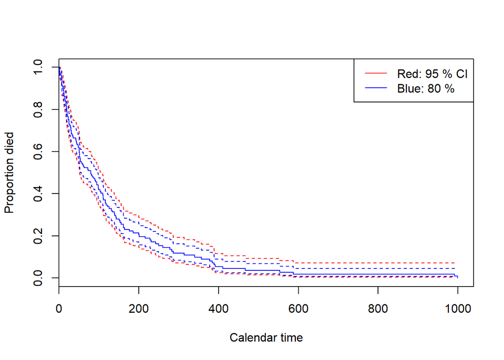

```r
plot(analyse1, col="red", xlab="Calendar time", ylab = "Proportion died")
# Change confidence interval
analyse1=survfit(Surv(time, status)~1, data=veteran, conf.int=0.8)
lines(analyse1, col="blue")
legend("topright", c("Red: 95 % CI", "Blue: 80 %"), lty=1, col=c("Red", "Blue"))
```

## b.

*Plot the Kaplan-Meier estimates of the survival functions separately for the two treatment groups (standard vs. test). Does there appear to be a difference between the two groups in survival?*

```r
analyse2=survfit(Surv(time, status)~trt, data=veteran, conf.int=0.95)#, conf.type="none")
analyse2
```

```
## Call: survfit(formula = Surv(time, status) ~ trt, data = veteran, conf.int = 0.95)
##
##        n events median 0.95LCL 0.95UCL
## trt=1 69     64  103.0      59     132
## trt=2 68     64   52.5      44      95
```

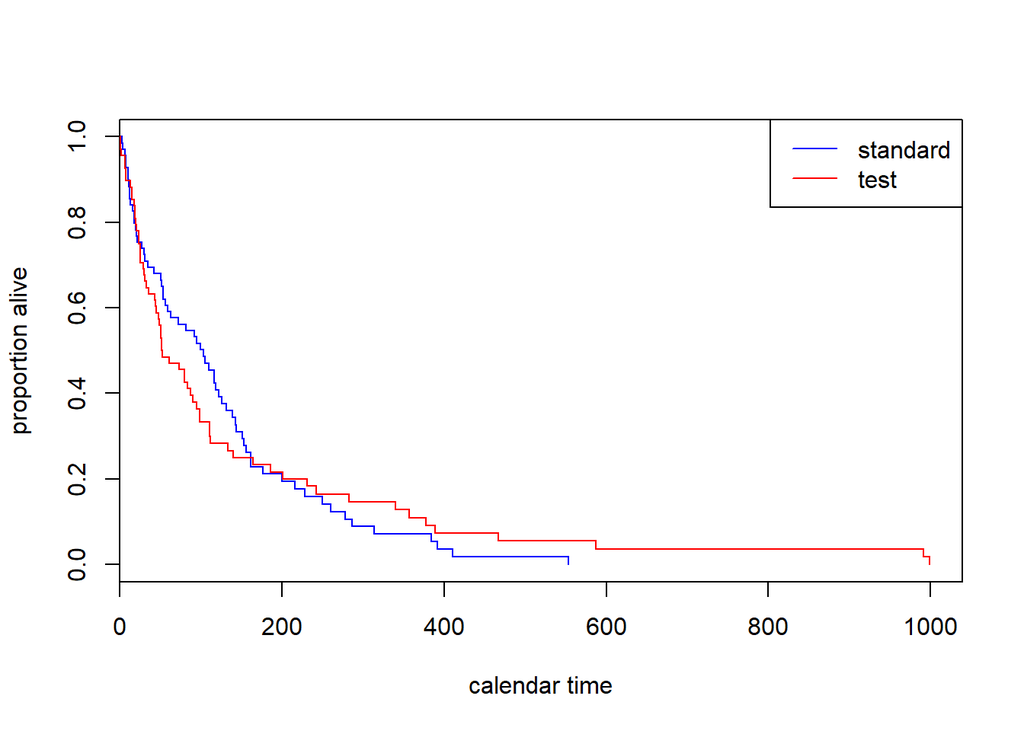

```r
plot(analyse2, col=c("blue", "red"), xlab="calendar time", ylab="proportion alive")
legend("topright", legend = c("standard", "test"), col=c("blue", "red"), lty=1)
```

*Irrespective of the treatment group, compare the survival in groups defined by the histological type of tumor (variable celltype). You may also like to explore the effect on survival of the other covariates in the data.*

Celltypes form two clusters. Smallcell and adeno have a steep survival function, large and squamous types less so. In terms of survival squamous cell type is advantageous.

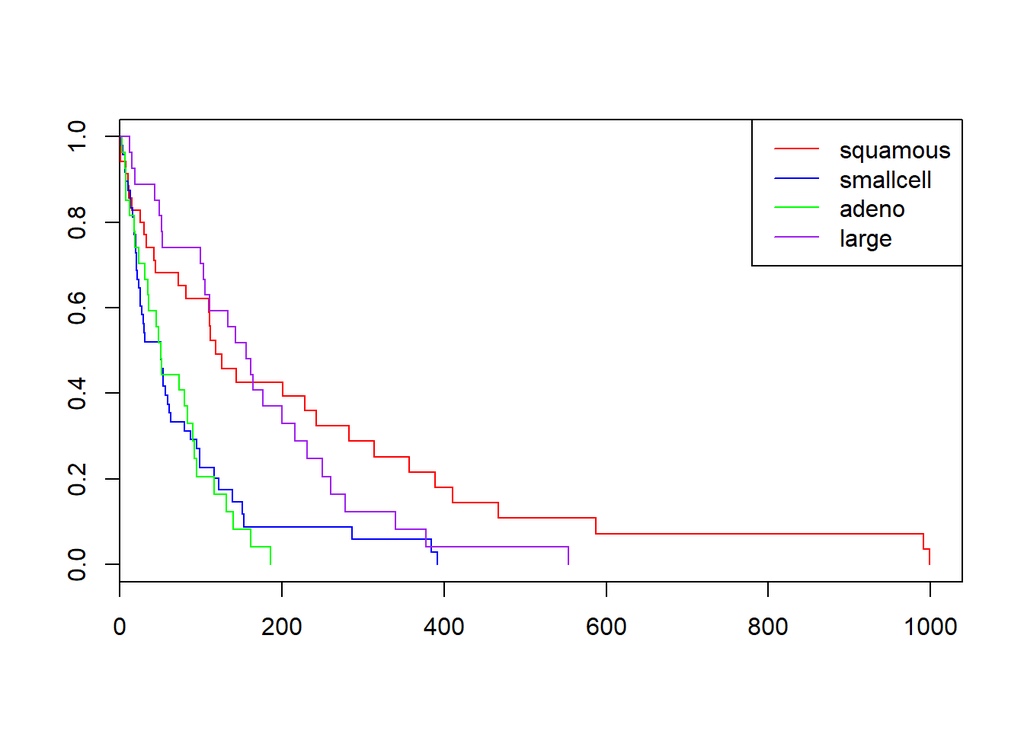

```r
analyse3=survfit(Surv(time, status)~celltype, data=veteran, conf.int=0.8)
plot(analyse3, col=c("red", "blue", "green", "purple"))
legend("topright", legend=levels(veteran$celltype), col=c("red", "blue", "green", "purple"), lty=1)
```

```r
print(analyse3)
```

```
## Call: survfit(formula = Surv(time, status) ~ celltype, data = veteran,
##     conf.int = 0.8)
##
##                     n events median 0.8LCL 0.8UCL
## celltype=squamous  35     31    118    110    228
## celltype=smallcell 48     45     51     27     56
## celltype=adeno     27     26     51     36     84
## celltype=large     27     26    156    111    200
```

## c.

*Compare the two treatments by the log-rank test. You can find this in the survdiff routine. Compare then the effect of celltype on survival.*

Survival function for the test group is higher than the standard group at times and lower at times. There is also no obvious difference that one treatment would clearly outperform the other.

Hypotheses for the log-rank-test are as follows: H0: There’s no difference between the survival functions of the two treatment groups. H1: There’s a difference between the groups.

survdiff output reveals that the probability for the to curves to be same or similar is 0.9, so it is very likely that null hypothesis should be more true.

```r
analyse3=survdiff(Surv(time, status)~trt, data=veteran)
print(analyse3)
```

```
## Call:
## survdiff(formula = Surv(time, status) ~ trt, data = veteran)
##
##        N Observed Expected (O-E)^2/E (O-E)^2/V
## trt=1 69       64     64.5   0.00388   0.00823
## trt=2 68       64     63.5   0.00394   0.00823
##
##  Chisq= 0  on 1 degrees of freedom, p= 0.9
```

For celltypes it seems that the survival functions of the different cell types are different (p<0.001), and null hypothesis doesn’t get support.

```r
analyse3=survdiff(Surv(time, status)~celltype, data=veteran)
print(analyse3)
```

```
## Call:
## survdiff(formula = Surv(time, status) ~ celltype, data = veteran)
##
##                     N Observed Expected (O-E)^2/E (O-E)^2/V
## celltype=squamous  35       31     47.7      5.82     10.53
## celltype=smallcell 48       45     30.1      7.37     10.20
## celltype=adeno     27       26     15.7      6.77      8.19
## celltype=large     27       26     34.5      2.12      3.02
##
##  Chisq= 25.4  on 3 degrees of freedom, p= 1e-05
```

Also if data is further stratified by variable prior therapy, groups are likeli to differ (p<0.001).

```r
library(RColorBrewer)
n <- 60
qual_col_pals = brewer.pal.info[brewer.pal.info$category == 'qual',]
col_vector = unlist(mapply(brewer.pal, qual_col_pals$maxcolors, rownames(qual_col_pals)))

library(magrittr)
legendtext=unique(veteran[, c("celltype", "prior")])
legendtext=unique(paste(veteran$celltype, veteran$prior))%>%
  sort()

analyse3a=survfit(Surv(time, status)~celltype+prior, data=veteran)
analyse3a
```

```
## Call: survfit(formula = Surv(time, status) ~ celltype + prior, data = veteran)
##
##                               n events median 0.95LCL 0.95UCL
## celltype=squamous, prior=0   21     19  128.0      72     357
## celltype=squamous, prior=10  14     12  118.0      44      NA
## celltype=smallcell, prior=0  37     35   51.0      25      87
## celltype=smallcell, prior=10 11     10   51.0      20      NA
## celltype=adeno, prior=0      22     21   51.5      36     117
## celltype=adeno, prior=10      5      5   18.0      12      NA
## celltype=large, prior=0      17     16  143.0     105     278
## celltype=large, prior=10     10     10  170.5      43      NA
```

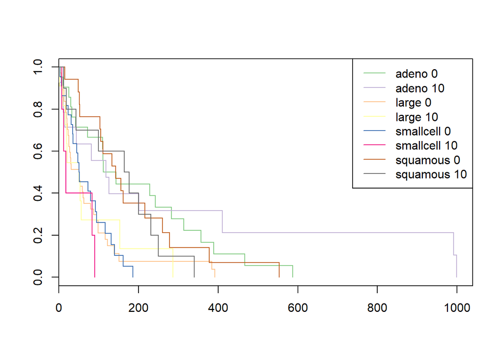

```r
plot(analyse3a, col=col_vector)
legend("topright", legend=legendtext, col=col_vector, lty=1)
```

```r
analyse3=survdiff(Surv(time, status)~celltype+prior, data=veteran)
print(analyse3)
```

```
## Call:
## survdiff(formula = Surv(time, status) ~ celltype + prior, data = veteran)
##
##                               N Observed Expected (O-E)^2/E (O-E)^2/V
## celltype=squamous, prior=0   21       19    27.73     2.749     3.641
## celltype=squamous, prior=10  14       12    19.92     3.151     4.397
## celltype=smallcell, prior=0  37       35    23.31     5.869     7.524
## celltype=smallcell, prior=10 11       10     6.80     1.510     1.622
## celltype=adeno, prior=0      22       21    13.78     3.778     4.449
## celltype=adeno, prior=10      5        5     1.91     4.997     5.187
## celltype=large, prior=0      17       16    22.56     1.906     2.364
## celltype=large, prior=10     10       10    11.99     0.331     0.376
##
##  Chisq= 28  on 7 degrees of freedom, p= 2e-04
```

# 4.

Data matrix cervix contains grouped survival data for two cohorts of women, diagnosed with stage I or stage II cervix cancer. Use the lifetab routine in R library KMsurv to create life tables for both groups.

```r
cervix=read.table("./Week1/exercise-data/cervix.dat", sep=";", header = T)
head(cervix); str(cervix)
```

```
##   year stage   N nfailure nlost
## 1    1     1 110        5     5
## 2    2     1 100        7     7
## 3    3     1  86        7     7
## 4    4     1  72        3     8
## 5    5     1  61        0     7
## 6    6     1  54        2    10
```

```
## 'data.frame':    20 obs. of  5 variables:
##  $ year    : int  1 2 3 4 5 6 7 8 9 10 ...
##  $ stage   : int  1 1 1 1 1 1 1 1 1 1 ...
##  $ N       : int  110 100 86 72 61 54 42 33 28 24 ...
##  $ nfailure: int  5 7 7 3 0 2 3 0 0 1 ...
##  $ nlost   : num  5 7 7 8 7 10 6 5 4 8 ...
```

```r
cervix1=cervix[cervix$stage==1,]
cervix2=cervix[cervix$stage==2,]
KMsurv::lifetab(tis=cervix1$year
                , ninit=cervix1[cervix1$year==1,]$N
                , nlost=cervix1$nlost
                , nevent=cervix1$nfailure
                )
```

```
##      nsubs nlost nrisk nevent      surv        pdf     hazard    se.surv
## 1-2    110     5 107.5      5 1.0000000 0.04651163 0.04761905 0.00000000
## 2-3    100     7  96.5      7 0.9534884 0.06916496 0.07526882 0.02031114
## 3-4     86     7  82.5      7 0.8843234 0.07503350 0.08860759 0.03144341
## 4-5     72     8  68.0      3 0.8092899 0.03570397 0.04511278 0.03954839
## 5-6     61     7  57.5      0 0.7735859 0.00000000 0.00000000 0.04284029
## 6-7     54    10  49.0      2 0.7735859 0.03157494 0.04166667 0.04284029
## 7-8     42     6  39.0      3 0.7420110 0.05707777 0.08000000 0.04654751
## 8-9     33     5  30.5      0 0.6849332 0.00000000 0.00000000 0.05337208
## 9-10    28     4  26.0      0 0.6849332 0.00000000 0.00000000 0.05337208
## 10-2    24     8  20.0      1 0.6849332         NA         NA 0.05337208
##          se.pdf  se.hazard
## 1-2  0.02031114 0.02128985
## 2-3  0.02521897 0.02842878
## 3-4  0.02726104 0.03345764
## 4-5  0.02022924 0.02603925
## 5-6         NaN        NaN
## 6-7  0.02193626 0.02945639
## 7-8  0.03186287 0.04615106
## 8-9         NaN        NaN
## 9-10        NaN        NaN
## 10-2         NA         NA
```

```r
KMsurv::lifetab(tis=cervix2$year
                , ninit=cervix2[cervix2$year==1,]$N
                , nlost=cervix2$nlost
                , nevent=cervix2$nfailure
                )
```

```
##      nsubs nlost nrisk nevent      surv        pdf     hazard    se.surv
## 1-2    234     3 232.5     24 1.0000000 0.10322581 0.10884354 0.00000000
## 2-3    207    11 201.5     27 0.8967742 0.12016329 0.14361702 0.01995374
## 3-4    169     9 164.5     31 0.7766109 0.14635221 0.20805369 0.02759940
## 4-5    129     7 125.5     17 0.6302587 0.08537369 0.14529915 0.03259466
## 5-6    105    13  98.5      7 0.5448850 0.03872279 0.07368421 0.03412842
## 6-7     85     6  82.0      6 0.5061622 0.03703626 0.07594937 0.03469969
## 7-8     73     6  70.0      5 0.4691260 0.03350900 0.07407407 0.03530150
## 8-9     62    10  57.0      3 0.4356170 0.02292721 0.05405405 0.03581977
## 9-10    49    10  44.0      2 0.4126898 0.01875863 0.04651163 0.03629805
## 10-2    37     6  34.0      4 0.3939311         NA         NA 0.03699242
##          se.pdf  se.hazard
## 1-2  0.01995374 0.02218467
## 2-3  0.02168584 0.02756776
## 3-4  0.02424416 0.03716481
## 4-5  0.01975252 0.03514710
## 5-6  0.01431319 0.02783111
## 6-7  0.01477609 0.03098383
## 7-8  0.01465906 0.03310420
## 8-9  0.01302118 0.03119672
## 9-10 0.01306399 0.03287979
## 10-2         NA         NA
```